# CITS4009 - Project 2

## Decision Tree Classifier with Fisher Score Features

```r
dt_fisher <- train_dt(train_fisher)
print(dt_fisher)
```

```
## CART
##
## 855 samples
##   7 predictor
##   2 classes: '0', '1'
##
## No pre-processing
## Resampling: Cross-Validated (10 fold)
## Summary of sample sizes: 770, 769, 769, 769, 769, 770, ...
## Resampling results across tuning parameters:
##
##   cp          Accuracy   Kappa
##   0.01927711  0.7683858  0.5371774
##   0.09156627  0.7345144  0.4689759
##   0.46746988  0.6059781  0.1974749
##
## Accuracy was used to select the optimal model using the largest value.
## The final value used for the model was cp = 0.01927711.
```

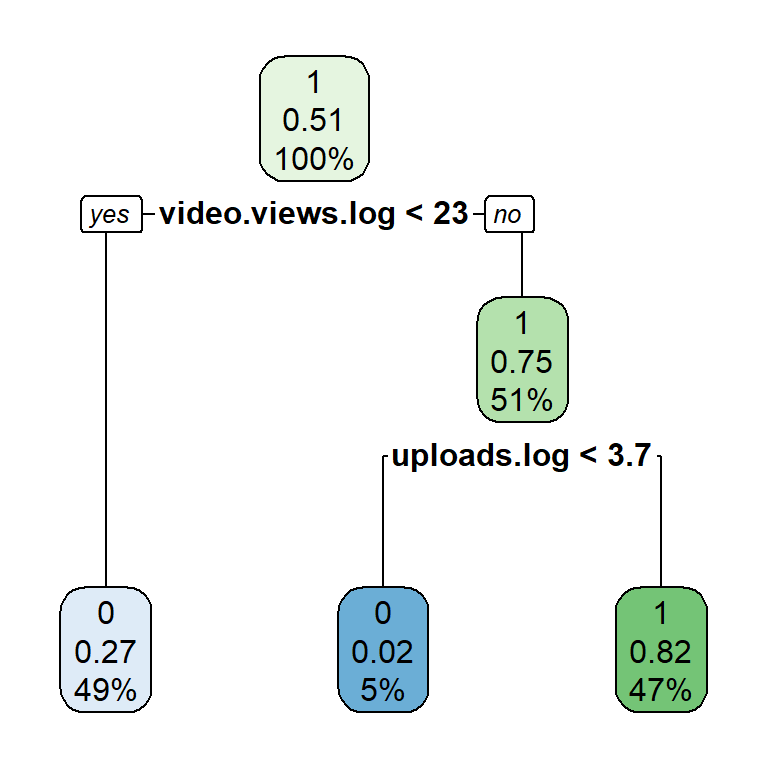

```r
train_class_dt <- as_tibble(predict(dt_fisher, newdata = train_fisher, type = "raw")) %>%
  rename(".pred_class" = value)
test_class_dt <- as_tibble(predict(dt_fisher, newdata = test_fisher, type = "raw")) %>%
  rename(".pred_class" = value)

train_pred_dt <- as_tibble(predict(dt_fisher, newdata = train_fisher, type = "prob")) %>%
  rename(".pred_0" = `0`, ".pred_1" = `1`)
test_pred_dt <- as_tibble(predict(dt_fisher, newdata = test_fisher, type = "prob")) %>%
  rename(".pred_0" = `0`, ".pred_1" = `1`)

rpart.plot(dt_fisher$finalModel)
```

The decision tree with Fisher Score features performed identically to the decision tree using forward selection features. This is because the tree made the splits using the same 2 features `video.views` and `uploads` as the other decision tree.

This indicates that the decision tree classifier ranks the importance of these 2 features very highly. However, this unfortunately did not produce different results for the tree.

```r
importances <- varImp(dt_fisher, scale = TRUE)
print(importances)
```

```
## rpart variable importance
##
##                                             Overall
## video.views.log                              100.00
## uploads.log                                   88.66
## Country                                       43.18
## channel_type                                  23.77
## subscribers.log                               21.98
## Population.log                                 0.00
## Gross.tertiary.education.enrollment.....log    0.00
```

```r
performance_dt_forward <- cal_scores(train_pca, train_class_dt, test_pca, test_class_dt)
print(performance_dt_forward$train)
```

```
## # A tibble: 1 × 4
##   Accuracy Precision Recall    F1
##      <dbl>     <dbl>  <dbl> <dbl>
## 1    0.786     0.754  0.829 0.790
```

```r
print(performance_dt_forward$calibration)
```

```
## # A tibble: 1 × 4
##   Accuracy Precision Recall    F1
##      <dbl>     <dbl>  <dbl> <dbl>
## 1    0.766     0.755  0.787 0.771
```

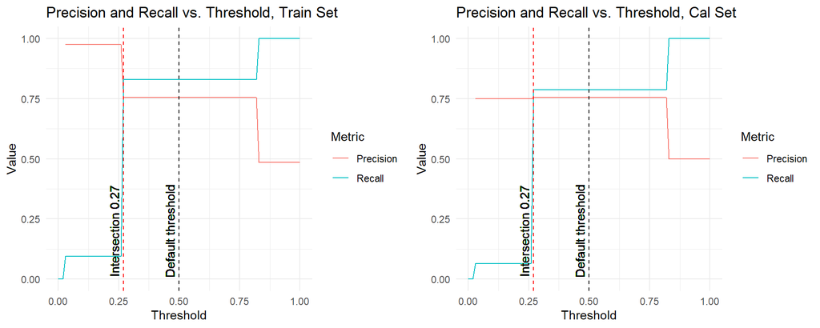

```r
p1 <- plot_precision_recall_vs_threshold(train_pred_dt, train_pca, "Precision and Recall vs. Threshold, Train Set")
p2 <- plot_precision_recall_vs_threshold(test_pred_dt , test_pca, "Precision and Recall vs. Threshold, Cal Set")
grid.arrange(p1, p2, ncol=2)
```

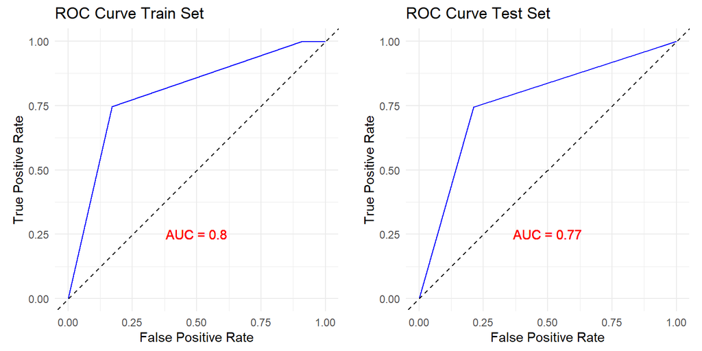

```r
p1 <- plot_roc(train_pred_dt, train_fisher, "ROC Curve Train Set")
p2 <- plot_roc(test_pred_dt, test_fisher, "ROC Curve Test Set")
grid.arrange(p1, p2, ncol=2)
```

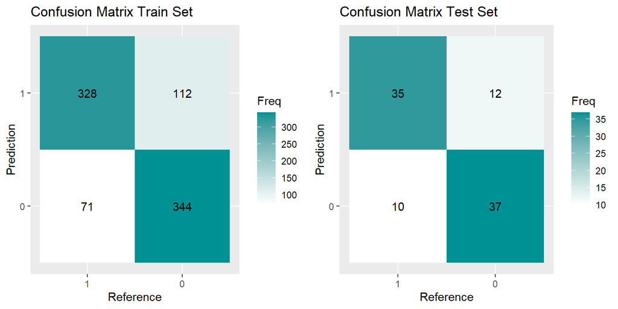

```r
p1 <- plot_con_matrix(train_class_dt, train_pca, "Confusion Matrix Train Set")
p2 <- plot_con_matrix(test_class_dt, test_pca, "Confusion Matrix Test Set")
grid.arrange(p1, p2, ncol=2)
```